# Homwork 1 - Stats 4620

```r
#iv.
Elite =rep("No",nrow(college ))
Elite [college$Top10perc >50]=" Yes"
college =data.frame(college ,Elite)
college$Elite =as.factor(college$Elite)
summary(college)
```

```
##  Private        Apps           Accept          Enroll       Top10perc
##  No :212   Min.   :   81   Min.   :   72   Min.   :  35   Min.   : 1.00
##  Yes:565   1st Qu.:  776   1st Qu.:  604   1st Qu.: 242   1st Qu.:15.00
##            Median : 1558   Median : 1110   Median : 434   Median :23.00
##            Mean   : 3002   Mean   : 2019   Mean   : 780   Mean   :27.56
##            3rd Qu.: 3624   3rd Qu.: 2424   3rd Qu.: 902   3rd Qu.:35.00
##            Max.   :48094   Max.   :26330   Max.   :6392   Max.   :96.00
##    Top25perc      F.Undergrad     P.Undergrad         Outstate
##  Min.   :  9.0   Min.   :  139   Min.   :    1.0   Min.   : 2340
##  1st Qu.: 41.0   1st Qu.:  992   1st Qu.:   95.0   1st Qu.: 7320
##  Median : 54.0   Median : 1707   Median :  353.0   Median : 9990
##  Mean   : 55.8   Mean   : 3700   Mean   :  855.3   Mean   :10441
##  3rd Qu.: 69.0   3rd Qu.: 4005   3rd Qu.:  967.0   3rd Qu.:12925
##  Max.   :100.0   Max.   :31643   Max.   :21836.0   Max.   :21700
##    Room.Board       Books           Personal         PhD
##  Min.   :1780   Min.   :  96.0   Min.   : 250   Min.   :  8.00
##  1st Qu.:3597   1st Qu.: 470.0   1st Qu.: 850   1st Qu.: 62.00
##  Median :4200   Median : 500.0   Median :1200   Median : 75.00
##  Mean   :4358   Mean   : 549.4   Mean   :1341   Mean   : 72.66
##  3rd Qu.:5050   3rd Qu.: 600.0   3rd Qu.:1700   3rd Qu.: 85.00
##  Max.   :8124   Max.   :2340.0   Max.   :6800   Max.   :103.00
##     Terminal       S.F.Ratio      perc.alumni        Expend
##  Min.   : 24.0   Min.   : 2.50   Min.   : 0.00   Min.   : 3186
##  1st Qu.: 71.0   1st Qu.:11.50   1st Qu.:13.00   1st Qu.: 6751
##  Median : 82.0   Median :13.60   Median :21.00   Median : 8377
##  Mean   : 79.7   Mean   :14.09   Mean   :22.74   Mean   : 9660
##  3rd Qu.: 92.0   3rd Qu.:16.50   3rd Qu.:31.00   3rd Qu.:10830
##  Max.   :100.0   Max.   :39.80   Max.   :64.00   Max.   :56233
##    Grad.Rate       Elite
##  Min.   : 10.00    Yes: 78
##  1st Qu.: 53.00   No  :699
##  Median : 65.00
##  Mean   : 65.46
##  3rd Qu.: 78.00
##  Max.   :118.00
```

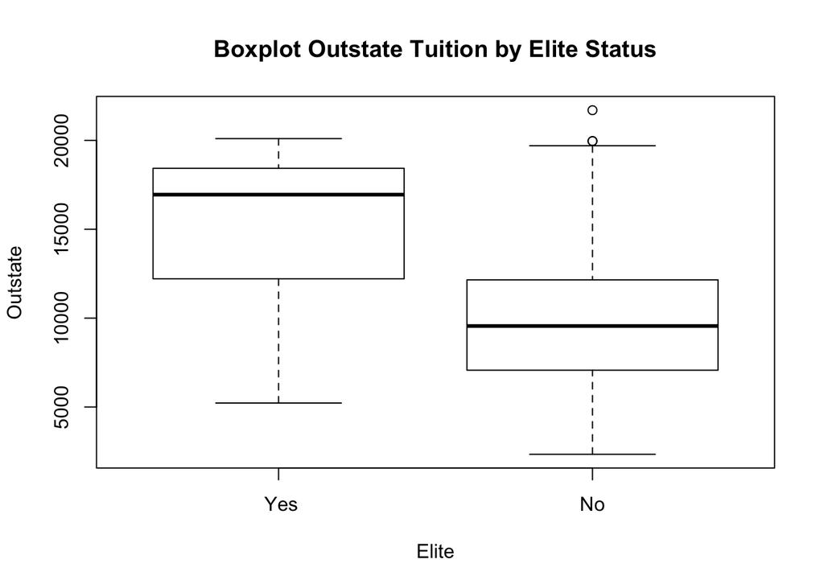

```r
boxplot(Outstate~Elite, main="Boxplot Outstate Tuition by Elite Status",
    xlab="Elite", ylab="Outstate")
```

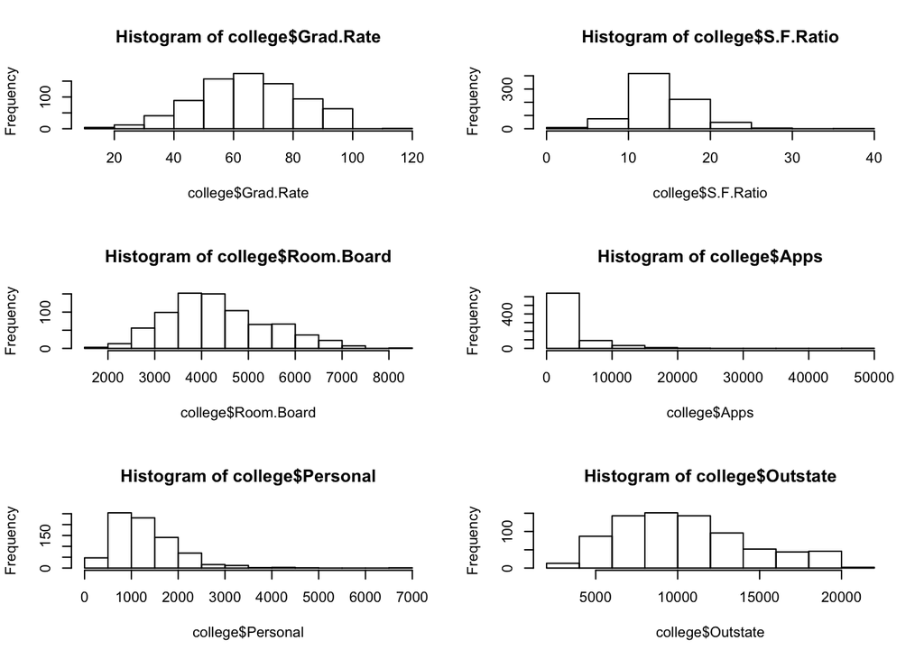

```r
#v.
par(mfrow=c(3,2))
hist(college$Grad.Rate)
hist(college$S.F.Ratio)
hist(college$Room.Board)
hist(college$Apps)
hist(college$Personal)
hist(college$Outstate)
```

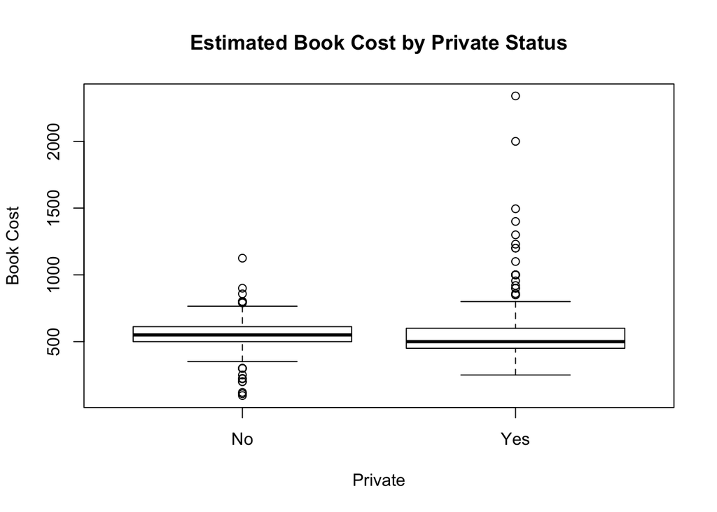

```r
#vi.

#Look into other cost variables and how Private status affects
par(mfrow=c(1,1))
boxplot(Books~Private, main="Estimated Book Cost by Private Status",
    xlab="Private", ylab="Book Cost")
```

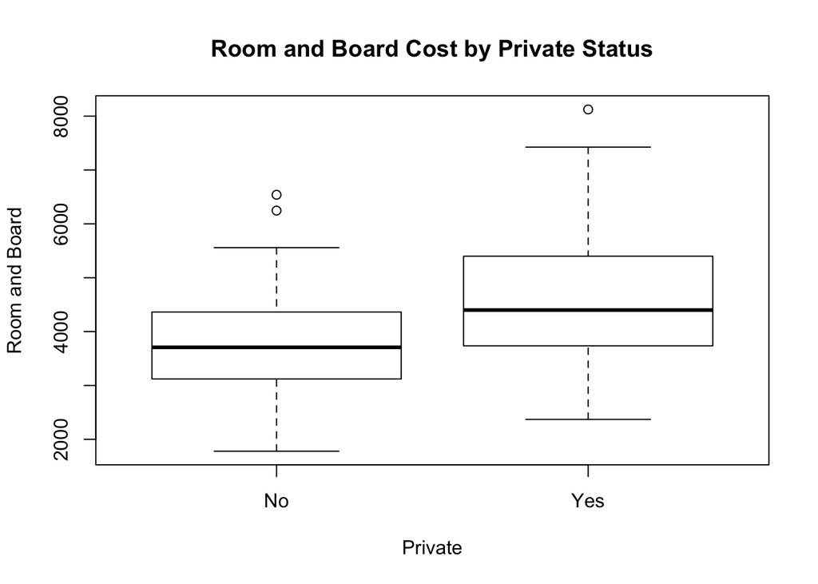

```r
boxplot(Room.Board~Private, main="Room and Board Cost by Private Status",
    xlab="Private", ylab="Room and Board")
```

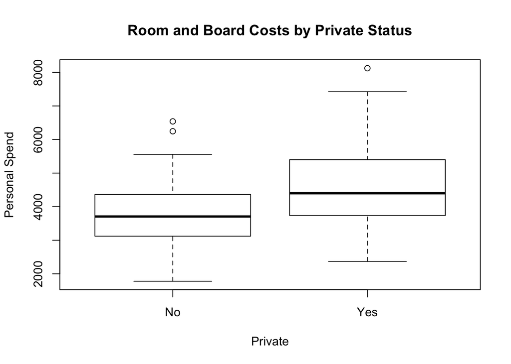

```r
boxplot(Room.Board~Private, main="Room and Board Costs by Private Status",
    xlab="Private", ylab="Personal Spend")
```

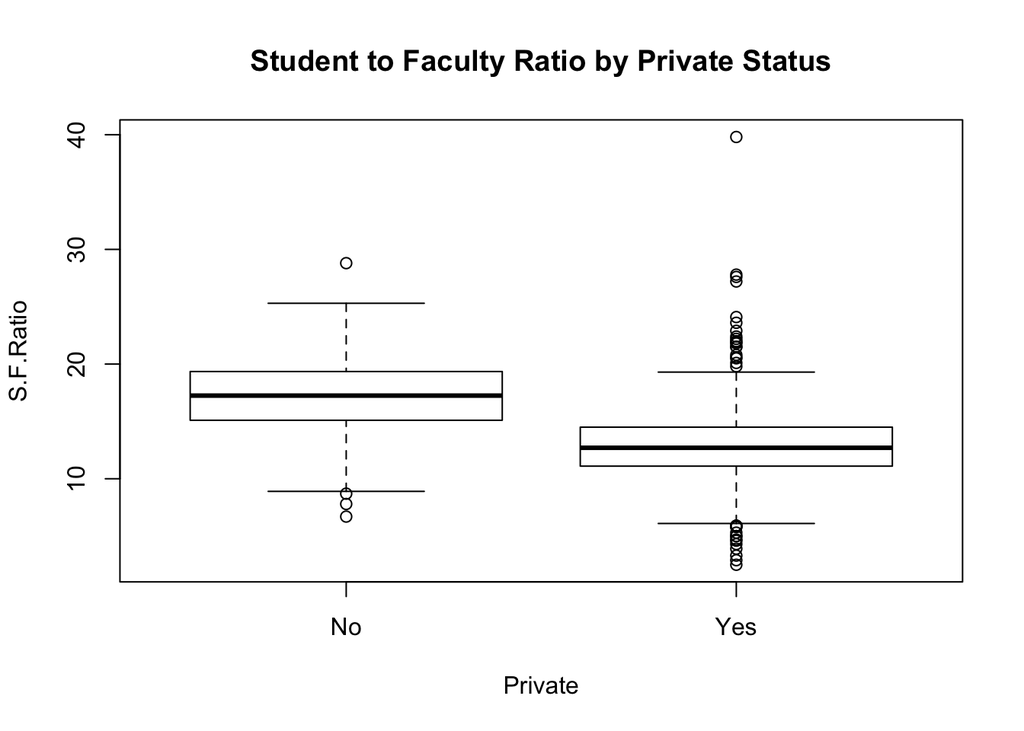

```r
#Are private school students getting more for their $?
boxplot(S.F.Ratio~Private, main="Student to Faculty Ratio by Private Status",
    xlab="Private", ylab="S.F.Ratio")
```

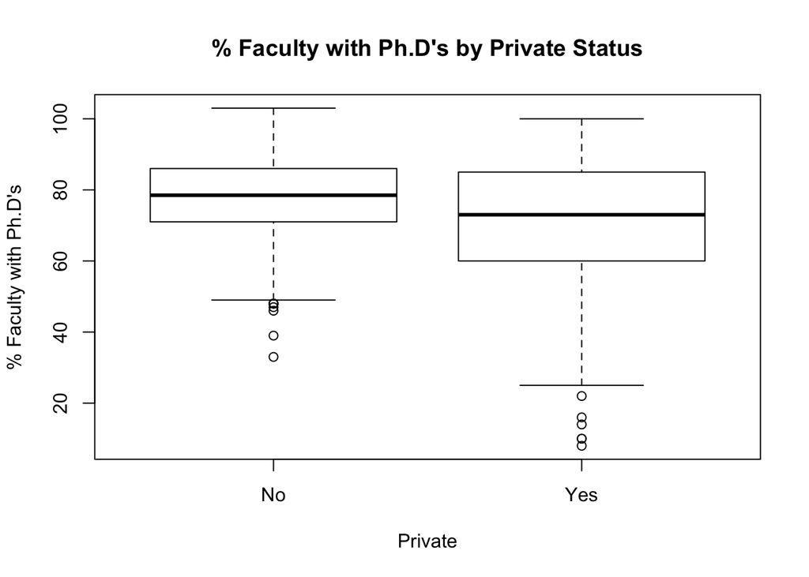

```r
boxplot(PhD~Private, main="% Faculty with Ph.D's by Private Status",
    xlab="Private", ylab="% Faculty with Ph.D's")
```

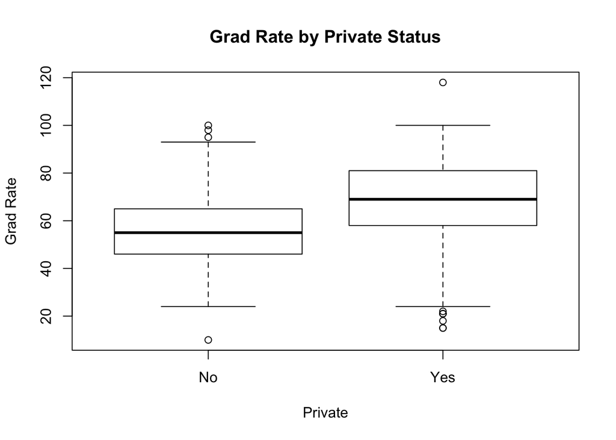

```r
boxplot(Grad.Rate~Private, main="Grad Rate by Private Status",
    xlab="Private", ylab="Grad Rate")
```

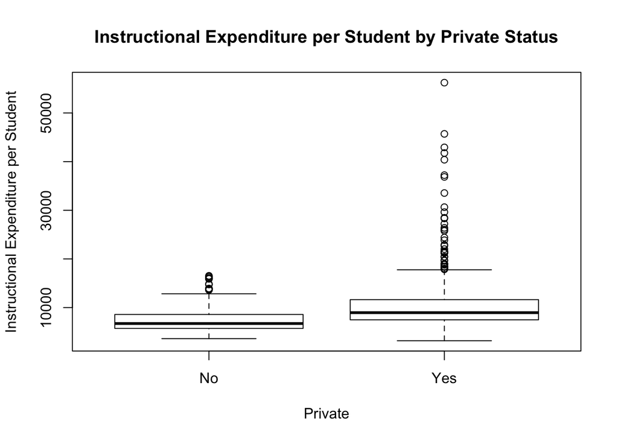

```r
boxplot(Expend~Private, main="Instructional Expenditure per Student by Private Status",
    xlab="Private", ylab="Instructional Expenditure per Student")
```

Private school have a smaller Student to Faculty Ratio, a higher Graduation Rate and a higher Instructional Expenditure per Student amount. However, the average Percent Faculty with Ph.D’s is smaller for private schools, which comes as a suprise, since one might assume more elite professors with higher creditials come with a school that costs more money.

```r
load('~/Desktop/All Stuff/School Stuff/STATS/Data/credit.Rdata')
print(length(newcredit))
```

```
## [1] 11
```

```r
#Summary for initial analysis
summary(newcredit)
```

```
##      Income           Limit           Rating          Cards
##  Min.   : 10.63   Min.   : 1160   Min.   :126.0   Min.   :1
##  1st Qu.: 23.73   1st Qu.: 3914   1st Qu.:301.0   1st Qu.:2
##  Median : 39.42   Median : 5198   Median :383.0   Median :3
##  Mean   : 50.35   Mean   : 5499   Mean   :406.6   Mean   :3
##  3rd Qu.: 63.73   3rd Qu.: 6438   3rd Qu.:465.5   3rd Qu.:4
##  Max.   :186.63   Max.   :13414   Max.   :949.0   Max.   :9
##       Age          Education        Gender   Student   Married
##  Min.   :24.00   Min.   : 5.00    Male :73   No :137   No :58
##  1st Qu.:41.50   1st Qu.:11.00   Female:82   Yes: 18   Yes:97
##  Median :53.00   Median :14.00
##  Mean   :55.23   Mean   :13.61
##  3rd Qu.:70.00   3rd Qu.:16.00
##  Max.   :89.00   Max.   :20.00
##             Ethnicity     Balance
##  African American:39   Min.   :   5.0
##  Asian           :42   1st Qu.: 332.0
##  Caucasian       :74   Median : 606.0
##                        Mean   : 666.3
##                        3rd Qu.: 916.5
##                        Max.   :1809.0
```

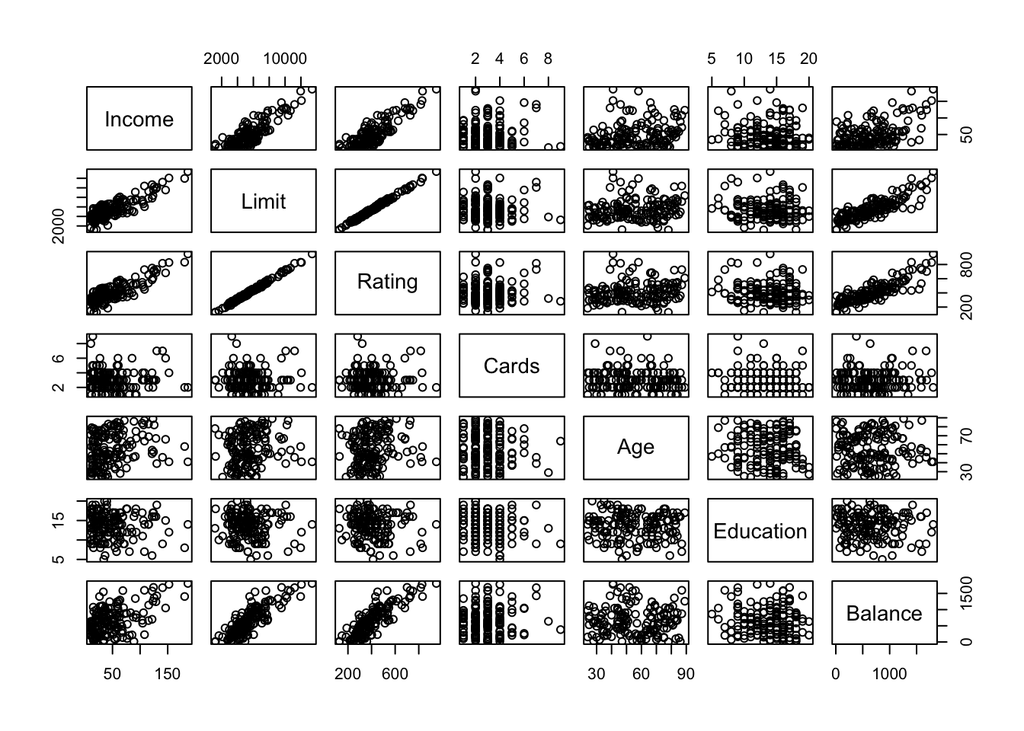

```r
keeps <- c("Income", "Limit", "Rating", "Cards", "Age", "Education", "Balance")
newcreditCont = newcredit[keeps]

#newcredit$Private =as.factor(college$Private)
attach(newcredit)

#Scatterplot variables
pairs(newcreditCont)
```

Of all the continuous variables, Limit and Rating appear to have the strongest (positive) correlation with Balance. Both correlations seem almost equal, which is not a suprise, since Limit and Rating themselves have an extremely high correlation between each other. Income is also highly correlated. My assumption is that we will only need one of these in the model as to avoid multicollinearity. The reltionship appears linear but it may be of a higher or lower degree, we will have to test this. Cards, Age, and Education don’t have high correlation, so the degree of information each of these would add to our model stands questionable.

Categorical variables and their affects on Balance are not easily analyized in a scatterplot such as the one above. We are going to construct boxplots, plotting Balance against these each categorical variable, as seen below. These charts are much more interpretable and make analysis easier.

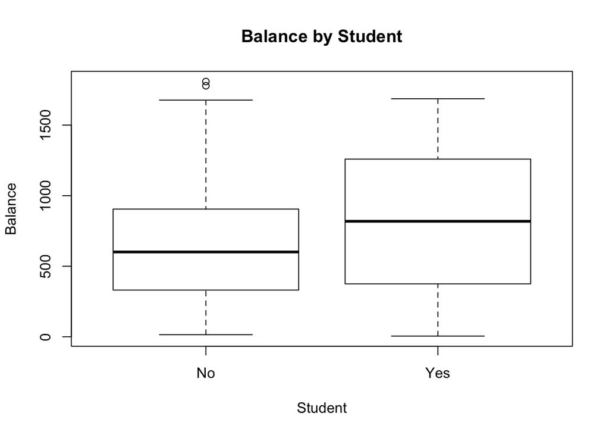

```r
#Student
boxplot(Balance~Student, main="Balance by Student",
    xlab="Student", ylab="Balance")
```

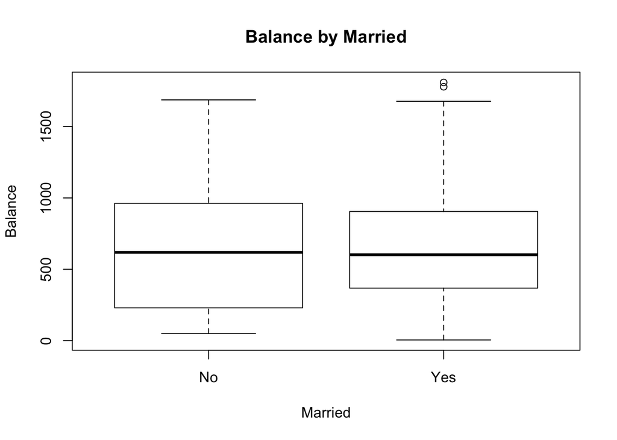

```r
#Married
boxplot(Balance~Married, main="Balance by Married",
    xlab="Married", ylab="Balance")
```

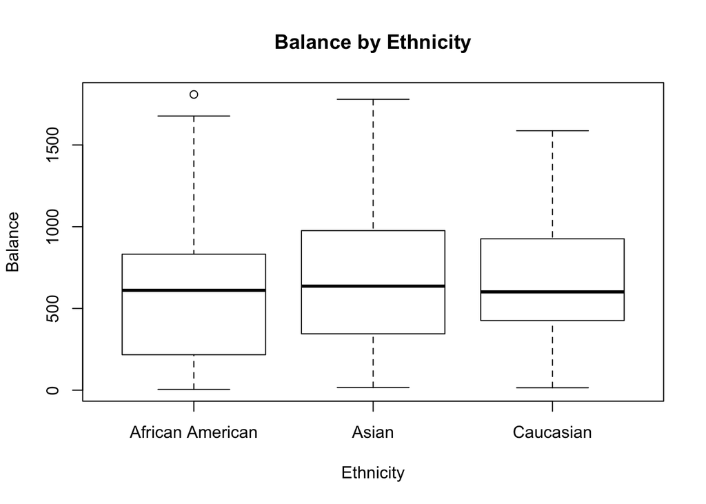

```r
#Ethnicity
boxplot(Balance~Ethnicity, main="Balance by Ethnicity",
    xlab="Ethnicity", ylab="Balance")
```

The scale of the y-axis on each of these plots is the same, which allows us to compare between plots. Of the three categorical variables charted, the Student has the most prominent difference in meen balance and thus might contribute the most to our model. The mean Balance between ethnicities varries some too, so we may still use Ethnicity. The two box and whiskers in the ‘Balance by Married’ chart, however, are quite similar, indicating marrital status does not impact Balance.

```r
#Rating? or Limit?
lmfit = lm( Balance ~ Rating)
summary(lmfit)
```

```
##
## Call:
## lm(formula = Balance ~ Rating)
##
## Residuals:
##     Min      1Q  Median      3Q     Max
## -546.67 -149.83   14.66  143.87  770.27
##
## Coefficients:
##              Estimate Std. Error t value Pr(>|t|)
## (Intercept) -363.3467    54.2676  -6.695 3.84e-10 ***
## Rating         2.5323     0.1259  20.111  < 2e-16 ***
## ---
## Signif. codes:  0 '***' 0.001 '**' 0.01 '*' 0.05 '.' 0.1 ' ' 1
##
## Residual standard error: 224.1 on 153 degrees of freedom
## Multiple R-squared:  0.7255, Adjusted R-squared:  0.7237
## F-statistic: 404.5 on 1 and 153 DF,  p-value: < 2.2e-16
```

```r
lmfit2 = lm( Balance ~ Limit)
summary(lmfit2)
```

```
##
## Call:
## lm(formula = Balance ~ Limit)
##
## Residuals:
##     Min      1Q  Median      3Q     Max
## -559.20 -153.44    7.14  134.55  763.76
##
## Coefficients:
##               Estimate Std. Error t value Pr(>|t|)
## (Intercept) -2.585e+02  5.049e+01   -5.12 9.08e-07 ***
## Limit        1.682e-01  8.557e-03   19.65  < 2e-16 ***
## ---
## Signif. codes:  0 '***' 0.001 '**' 0.01 '*' 0.05 '.' 0.1 ' ' 1
##
## Residual standard error: 227.8 on 153 degrees of freedom
## Multiple R-squared:  0.7162, Adjusted R-squared:  0.7144
## F-statistic: 386.2 on 1 and 153 DF,  p-value: < 2.2e-16
```

The model using Rating resulted in a smaller Residual standard error and larger Multiple R-squared (though they were both close, of course), so we will stick with that.

```r
#Seeing how addition of student affects fit
lmfit3 = lm( Balance ~ Rating+ Student)
summary(lmfit3)
```

```
##
## Call:
## lm(formula = Balance ~ Rating + Student)
##
## Residuals:
##    Min     1Q Median     3Q    Max
## -510.9 -123.5   11.3  145.1  451.0
##
## Coefficients:
##              Estimate Std. Error t value Pr(>|t|)
## (Intercept) -456.3793    48.7691  -9.358  < 2e-16 ***
## Rating         2.6598     0.1105  24.062  < 2e-16 ***
## StudentYes   354.8117    49.3132   7.195 2.66e-11 ***
## ---
## Signif. codes:  0 '***' 0.001 '**' 0.01 '*' 0.05 '.' 0.1 ' ' 1
##
## Residual standard error: 194.2 on 152 degrees of freedom
## Multiple R-squared:  0.7953, Adjusted R-squared:  0.7926
## F-statistic: 295.2 on 2 and 152 DF,  p-value: < 2.2e-16
```

Adding student decreased our RSE and increased our R-squared, awesome, definitely going to add to our model. Now that we have the essentials, lets see how the remaining variables effect the simple linear model that models Balance.

```r
#Income
model = lm( Balance ~ Rating+ Student + Income)
print(sprintf('%s : %s' ,'Income', summary(model)$sigma))
```

```
## [1] "Income : 53.1069024261126"
```

```r
#Married
model = lm( Balance ~ Rating+ Student + Married)
print(sprintf('%s : %s' ,'Married', summary(model)$sigma))
```

```
## [1] "Married : 194.715559567576"
```

```r
#Ethnicity
model = lm( Balance ~ Rating+ Student + Ethnicity)
print(sprintf('%s : %s' ,'Ethnicity', summary(model)$sigma))
```

```
## [1] "Ethnicity : 189.824327630236"
```

```r
#Cards
model = lm( Balance ~ Rating+ Student + Cards)
print(sprintf('%s : %s' ,'Cards', summary(model)$sigma))
```

```
## [1] "Cards : 194.377242212607"
```

```r
#Age
model = lm( Balance ~ Rating+ Student + Age)
print(sprintf('%s : %s' ,'Age', summary(model)$sigma))
```

```
## [1] "Age : 184.517947231624"
```

```r
#Education
model = lm( Balance ~ Rating+ Education + Age)
print(sprintf('%s : %s' ,'Education', summary(model)$sigma))
```

```
## [1] "Education : 218.416374283862"
```

Income is certainly a must add. From here, we will use an anova table to explore the addition of any other variables. I’ll form the anova table in order of the variables above that corresponded to the smallest residual standard error first.

```r
#lmfit5 = lm( Balance ~ I(Rating^.8)+ Student + Income + Age + Ethnicity + Cards + Married + Education)
lmfit4 = lm( Balance ~ Rating+ Student + Income + Age + Ethnicity + Cards + Married + Education)
anova(lmfit4)
```

```
## Analysis of Variance Table
##
## Response: Balance
##            Df   Sum Sq  Mean Sq   F value    Pr(>F)
## Rating      1 20304749 20304749 8560.6710 < 2.2e-16 ***
## Student     1  1951440  1951440  822.7453 < 2.2e-16 ***
## Income      1  5303792  5303792 2236.1279 < 2.2e-16 ***
## Age         1    66888    66888   28.2006 4.027e-07 ***
## Ethnicity   2    11001     5500    2.3190    0.1020
## Cards       1      624      624    0.2632    0.6087
## Married     1     1601     1601    0.6751    0.4126
## Education   1     1837     1837    0.7747    0.3802
## Residuals 145   343920     2372
## ---
## Signif. codes:  0 '***' 0.001 '**' 0.01 '*' 0.05 '.' 0.1 ' ' 1
```

```r
finalModel1 =lm( Balance ~ Rating+ Student + Income + Age)
summary(finalModel1)
```

```
##
## Call:
## lm(formula = Balance ~ Rating + Student + Income + Age)
##
## Residuals:
##      Min       1Q   Median       3Q      Max
## -120.863  -32.930    0.652   32.576  105.925
##
## Coefficients:
##               Estimate Std. Error t value Pr(>|t|)
## (Intercept) -781.26325   19.46918 -40.128  < 2e-16 ***
## Rating         4.75957    0.05346  89.035  < 2e-16 ***
## StudentYes   467.33399   12.65081  36.941  < 2e-16 ***
## Income        -9.43534    0.21108 -44.701  < 2e-16 ***
## Age           -1.20988    0.22885  -5.287 4.32e-07 ***
## ---
## Signif. codes:  0 '***' 0.001 '**' 0.01 '*' 0.05 '.' 0.1 ' ' 1
##
## Residual standard error: 48.92 on 150 degrees of freedom
## Multiple R-squared:  0.9872, Adjusted R-squared:  0.9868
## F-statistic:  2886 on 4 and 150 DF,  p-value: < 2.2e-16
```

```r
finalModel2 =lm( Balance ~ I(Rating^2)+ Student + Income + Age)
summary(finalModel2)
```

```
##
## Call:
## lm(formula = Balance ~ I(Rating^2) + Student + Income + Age)
##
## Residuals:
##     Min      1Q  Median      3Q     Max
## -830.24  -86.39   21.65  113.51  353.46
##
## Coefficients:
##               Estimate Std. Error t value Pr(>|t|)
## (Intercept)  2.467e+02  4.460e+01   5.533 1.37e-07 ***
## I(Rating^2)  4.528e-03  1.872e-04  24.191  < 2e-16 ***
## StudentYes   3.360e+02  4.111e+01   8.172 1.17e-13 ***
## Income      -8.999e+00  7.405e-01 -12.153  < 2e-16 ***
## Age         -1.320e-01  7.663e-01  -0.172    0.863
## ---
## Signif. codes:  0 '***' 0.001 '**' 0.01 '*' 0.05 '.' 0.1 ' ' 1
##
## Residual standard error: 162.2 on 150 degrees of freedom
## Multiple R-squared:  0.8591, Adjusted R-squared:  0.8553
## F-statistic: 228.6 on 4 and 150 DF,  p-value: < 2.2e-16
```

```r
pwrs = c(.4,.5,.6,.7,.8,.9,1.0,1.1,1.2,1.3,1.4,1.5,1.6,1.7,1.8,1.9,2.0)
#Quotient?
for (i in pwrs){
    #model = lm(Balance ~ poly(Rating, i))
    model = lm(Balance ~ I(Rating^i)+ Student + Income + Age)

    print(sprintf('%s : %s' ,i, summary(model)$sigma))
}
```

```
## [1] "0.4 : 94.7883694773213"
## [1] "0.5 : 83.2714941151627"
## [1] "0.6 : 72.246806932736"
## [1] "0.7 : 62.2665284227645"
## [1] "0.8 : 54.2218569084508"
## [1] "0.9 : 49.3710757325043"
## [1] "1 : 48.9205999616659"
## [1] "1.1 : 53.1385879325552"
## [1] "1.2 : 61.1318270532806"
## [1] "1.3 : 71.639123599256"
## [1] "1.4 : 83.6524430350291"
## [1] "1.5 : 96.5020696520658"
## [1] "1.6 : 109.755575511632"
## [1] "1.7 : 123.124180704386"
## [1] "1.8 : 136.405461104815"
## [1] "1.9 : 149.451620608373"
## [1] "2 : 162.152117421008"
```

Adding a second degree polynomial to the continuous variable Rating did not add much information at all. 1.0 also has the lowest residual sum of squares when testing all possible models with the Rating quotient ranging from 0.4-2.0. For sake of simplicity and interpretability, we will keep the degree equal to 1.0.

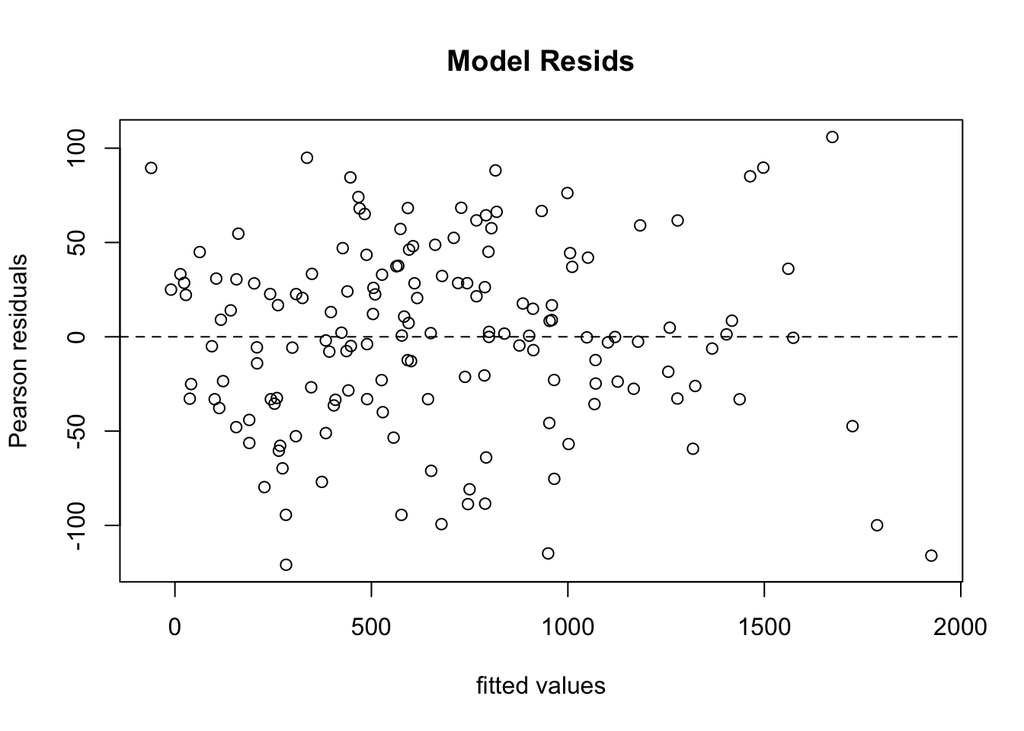

```r
fits <- fitted(finalModel1)
## calculate the deviance residuals
dev.resids  <- resid(finalModel1)
plot(fits, dev.resids,
     xlab="fitted values", ylab="Pearson residuals" ,main = "Model Resids")
abline(h=0, lty=2)
```

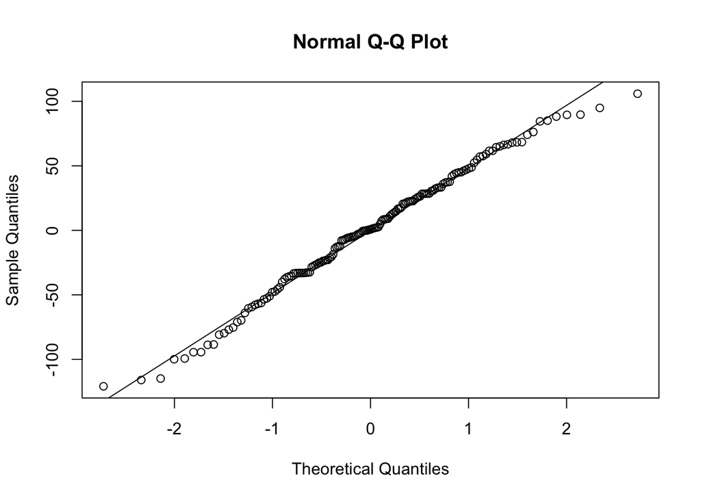

```r
#QQ to see if residuals follow normal
qqnorm(finalModel1$residuals)
qqline(finalModel1$residuals)
```

The redisuals look good. They follow the normal qqline well, they experience the same variance across all fitted values (homoscedasticity), and they are centered about zero. This indicates a strong linear model that will predict credit balance accurately.

Question 4 The reducible error can be broken down into the variance of the function $f(x)$ and the squared bias of $f(x)$ as follows:  
MSE = $E[(y_0-\hat{f}(x))^2]$  
$= E[(y_0-E[\hat{f}(x)]+E[\hat{f}(x)]-\hat{f}(x))^2]$  
$= E[(y_0-E[\hat{f}(x)])^2+2((y_0-E[\hat{f}(x)])(E[\hat{f}(x)]-\hat{f}(x)))+(E[\hat{f}(x)]-\hat{f}(x))^2]$  
$= E[(y_0-E[\hat{f}(x)])^2] +2E[y_0-E(\hat{f}(x)))(E(\hat{f}(x))-y_0)]+E[(E(\hat{f}(x))-\hat{f}(x)^2]$  
$= E[(y_0-E[\hat{f}(x)])^2] + 2E(y_0-(E(\hat{f}(x)))E(\hat{f}(x)-E(\hat{f}(x)))+E[(E(\hat{f}(x))-\hat{f}(x))^2]$  
$= E[(y_0-E[\hat{f}(x)])^2] + E[(E(\hat{f}(x))-\hat{f}(x))^2]$  
The irreducible error is the variance of the error terms for $f(x)$ and cannot be accounted for in the estimated function. Therefore the MSE is comprised of the variance of the estimated function, the squared bias, and the variance of the error terms.